# Creating a new framework-based application

Dr. Connie Brett

2025-09-04

# Overview

## Purpose

*periscope2* is a scalable and UI-standardized ‘shiny’ framework including a variety of developer convenience functions with the goal of both streamlining robust application development and assisting in creating a consistent user experience regardless of application or developer.

*periscope2* is rich of developer-friendly features as:

- Predefined but flexible templates for new Shiny applications with a default [bs4Dash](https://bs4dash.rinterface.com/) layout
- Separation by file of functionality that exists in one of the three shiny scopes: global, server-global, and server-local
- Generated applications are organized in an easy to follow and maintain folder structure based on files functionality
- Off-the-shelf and ready to be used modules (‘Table Downloader’, ‘Plot Downloader’, ‘File Downloader’ and ‘Reset Application’
- Different methods and tools to alert users and add useful information about application UI and server operations
- Application logger with different levels and a UI tool to display and review recorded application logs
- Application look and feel can be customized easily via ‘www/periscope_style.yaml’ or more advanced via ‘www/css/custom.css’
- Application can make use of JS power by customizing ‘www/js/custom.js’

## UI Sections

periscope2 layout depends on [bs4Dash](https://bs4dash.rinterface.com/index.html) layout as each application can have up to 5 different sections.

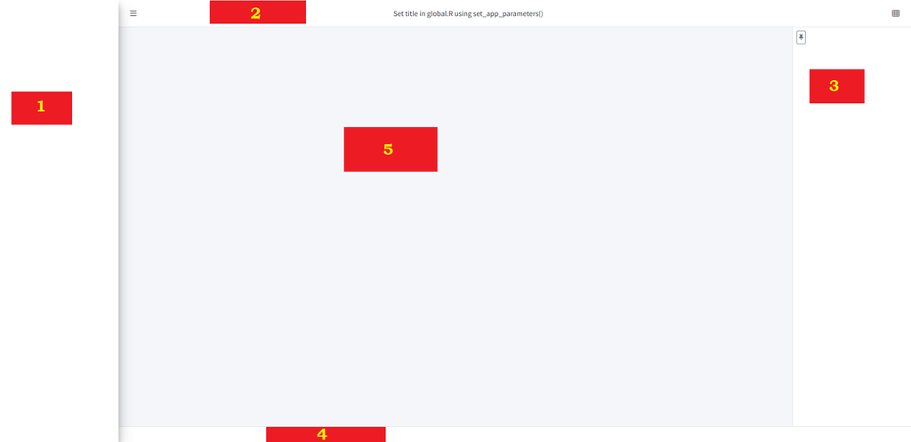

*1: Left Sidebar*

The left sidebar is largely intended for configuration options, settings, and general user application controls and functionality that will affect the body of the application.

Left sidebar supports any shiny UI element. In a multi-page app there can also be menu items in which each item can be linked to a separate body page.

The left sidebar can be collapsed in desktop mode to maximize the user’s view of the application body when they do not immediately need the configuration options and settings. Also, it is possible to create an application without a left sidebar.

*2: Header*

periscope2 uses the header to display the application title and any additional application information.

It is also used for displaying session busy indicator and announcements alerts.

Header can also be used to hold custom menu items to link to other apps, pages or any custom functions.

*3: Right Sidebar*

The right sidebar is, like the left sidebar, largely intended for configuration options, settings, and general user application controls and functionality that will affect the body of the application.

The right sidebar is optional. When used it is collapsed by default and can be opened by clicking on the icon (which can be customized).

*4: Footer*

The footer supports short textual or html formatted info/citations.

*5: Body*

This is the main body area for applications where charts and figures, tables, etc. are placed by the application developer. If desired the developer can add multiple pages or views and switch among them from menu options in the left sidebar, right sidebar or header sections.

## Features

### New Application Template Generation

- User can generate two main types of applications:
  - **Empty application** - ready for the user to drop in their code!
  - **Sample application** - demonstrates framework features in a working application
- To generate a sample application, set `sample_app` parameter in `create_application` to `TRUE`
  - Default value is `FALSE`
- Other sub-types will be based on enabling/disabling left and right sidebars
  - Default is to enable left sidebar and disable right sidebar
- Review `?create_application` for more details

### Built-in Conveniences

#### Responsive UI

The application layout will adapt to user device size automatically by re-flowing the content.

#### Application Busy Indicator

This indicator shows in the header bar automatically when the shiny application is busy. There is no code or configuration necessary to tie in this functionality.

#### Logging

The framework makes it easy to log user actions. Framework user interactions are automatically logged. Recorded logs can be viewed automatically using logViewer module

```r
# Add a user action to the log
loginfo("Your Information Message with %s, %s parameters", parm1, parm2, logger = ss_userAction.Log)

# Add a warning to the log
logwarn("Your Warning Message!", logger = ss_userAction.Log)
```

*Examples of app log in console:*

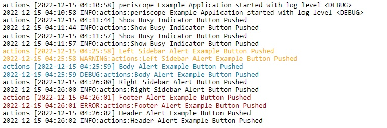

#### Alerting

There are five standardized locations for user-alerts:

- application header

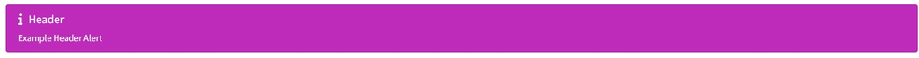

- the top of the body

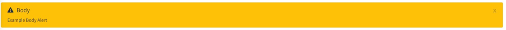

- footer

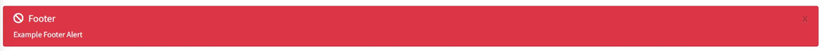

- left sidebar

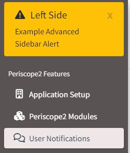

- right sidebar

All alerts can be dismissed by the user and are colored by setting the status.

Alerts can accumulate (i.e. append to each other) or replace previous alerts.

```r
createPSAlert(id      = 'bodyAlert',
              options = list(title    = 'alert title',
                             status   = 'warning',
                             closable = TRUE,
                             content  = alert contents))
# id is the location of the alert and can be one of:
#   'sidebarRightAlert', 'sidebarBasicAlert', 'bodyAlert', 'footerAlert' and 'headerAlert'

# status sets the bootstrap styling and can be one of:
#    'primary', 'success', 'warning', 'danger' or 'info'
```

#### Application Loading

An indicator that displayed upon application start up or reload and it can be customized in ‘program/global.R’

#### UI Tooltips

Tooltips can be added with the following code in the UI:

```r
ui_tooltip(id        = 'tooltipID',
           label     = 'label text (optional)',
           text      = 'text content',
           placement = 'top')

# placement sets the tool-tip pop-up location and can be one of:
# 'top', 'bottom', 'left' or 'right'
```

### Shiny Modules

#### downloadFile

This is a highly-functional set of custom-styled buttons with the built-in ability to download data in different file formats

*See the downloadFileButton Vignette for more detailed information*

#### downloadableTable

This is a highly-functional custom styled table that includes a downloadFileButton linked to the data

*See the downloadableTable Vignette for more detailed information*

#### downloadablePlot

This is a custom plot output that is paired with a linked downloadFile button that allows the user to download the plot (and optionally data) in different file formats

*See the downloadablePlot Vignette for more detailed information*

#### Announcement Module

This adds the ability to alert the app’s users with customized messages at the top of the application on startup. This is configurable using the ‘program/config/announce.yaml’ file.

*See the Announcement Vignette for more detailed information*

#### Application Reset

Resets a user’s session and rolls over their log

*See the Application Reset Vignette for more detailed information*

#### Log Viewer

View application session recorded log

*See the Log Viewer Vignette for more detailed information*

# Creating a Sample Application

## Step 1: Generate

```r
library(periscope2)
app_dir = tempdir()

# application without a right sidebar
create_application(name       = 'mytestapp',
                   location   = app_dir,
                   sample_app = TRUE)

# application without a left sidebar or a right sidebar
create_application(name         = 'mytestapp',
                   location     = app_dir,
                   sample_app   = TRUE,
                   left_sidebar = FALSE)

# application with left and right sidebars
create_application(name          = 'mytestapp',
                   location      = app_dir,
                   sample_app    = TRUE,
                   right_sidebar = TRUE)
```

This generates a default sample application optionally with a left/right sidebar in a subdirectory named *mytestapp* at the specified location. The location must exist when calling this function.

*Note*: If the *mytestapp* directory in this location already exists it will not be overwritten - the function will give a warning and exit without modifying the user’s system.

## Step 2: Run

```r
runApp(paste(app_dir, 'mytestapp', sep = .Platform$file.sep))
```

The application will run in either the viewer or browser (depending on system preferences/settings). It will contain help text, test buttons, a sample log, etc. You can use this sample application to explore the functionality and code.

# Creating your Application

## Step 1: Generate a Blank Application

```r
library(periscope2)
app_dir = tempdir()

# application without a right sidebar
create_application(name     = 'mytestapp',
                   location = app_dir)

# application without a left sidebar or a right sidebar
create_application(name         = 'mytestapp',
                   location     = app_dir,
                   left_sidebar = FALSE)

# application with a right sidebar
create_application(name          = 'mytestapp',
                   location      = app_dir,
                   right_sidebar = TRUE)
```

This generates a default blank application optionally with a left/right sidebar in a subdirectory named *mytestapp* at the specified location. The location must exist when calling this function.

*Note*: If the *mytestapp* directory in this location already exists it will not be overwritten - the function will give a warning and exit without modifying the directory.

## Step 2: Run (optional)

```r
runApp('mytestapp', appDir = app_dir)
```

It is recommended to run the empty application after creation to ensure a proper setup before beginning to customize the application.

## Step 3: Customize

All user customization is done in the files in the **program** subdirectory. We’ll walk through a few examples of how to add components and functionality as in a typical shiny application using this framework.

### program/global.R

Set your application title, version, information, loading_indicator, announcements_file and change the logging level using *set_app_parameters()*.

The *app_version* parameter in this function has a default value of “1.0.0”. It is recommended to follow the best practice in R’s packaging versioning. This means that a version consists of 3 numbers, *<major>.<minor>.<patch>*.

The *titleinfo* parameter in this function can be:

- NULL - The application title will be plain text with no extra functionality
- URL (character string) - The application title will be a clickable link that will send the user to an external URL location. Any html-valid url can be used to link to an accessible file location, http location, mailto: functionality or javascript.
- HTML code - The html will be placed into a pop-up modal window that will be shown when the user clicks the title link. Create the value using the shiny::HTML() function.

The *announcements_file* parameter points to the announcements module configuration file. Set this parameter to NULL to disable this feature

*Important:* Any variables or functions placed into this file are globally scoped and will be available across all user sessions.

```r
# Plain text title
set_app_parameters(title = "My Application Title")

# Application Title links to an external url
set_app_parameters(title     = "My Application Title",
                   titleinfo = "Application Valid Website")

# Application Title links to a modal window with HTML content
set_app_parameters(title     = "My Application Title",
                   titleinfo = HTML("<h3>This is information about this application</h3>",
                                    "<p><b>Author: </b>Me</p>",
                                    "<p><b>Date: </b>", Sys.Date(), "</p>"))

# Application Title links to a modal window with HTML content, setting log level to 'DEBUG',
# using simple loading screen, init app version and pass announcements configuration module file
set_app_parameters(title              = "periscope Example Application",
                   app_info           = HTML("Demonstrate periscope features and generated application layout"),
                   log_level          = "DEBUG",
                   app_version        = "1.0.0",
                   loading_indicator  = list(html = tagList(spin_1(), "Loading ...")),
                   announcements_file = "./program/config/announce.yaml")
```

### program/ui_left_sidebar.R

Create UI components for the left sidebar and register them with the framework using a call to *add_ui_left_sidebar()*

```r
sidebar_menu <-  sidebarMenu(
    sidebarHeader("Periscope2 Features"),
    menuItem(
        "Application Setup",
        tabName = "application_setup",
        icon    = icon("building")
    ),
    menuItem(
        "Periscope2 Modules",
        tabName = "periscope_modules",
        icon    = icon("cubes")
    ),
    menuItem(
        "User Notifications",
        tabName = "user_notifications",
        icon    = icon("comments")
    )
)

add_ui_left_sidebar(sidebar_menu = list(sidebar_menu))
```

### program/ui_right_sidebar.R

Create UI components for the right sidebar and register them with the framework using a call to *add_ui_right_sidebar()*.

```r
sidebar_element <- div(checkboxInput("hideFileOrganization", "Show Files Organization"))

add_ui_right_sidebar(sidebar_elements = list(sidebar_element))
```

### program/ui_body.R

Create UI components for the body and register them with the framework using a call to *add_ui_body()*. Use box elements for consistent presentation of your UI sections. Remember that different layout options and different box types configured in [bs4Dash](https://bs4dash.rinterface.com/index.html) can be used.

```r
body1 <- box(id          = "bodyElement1",
             title       = "Box 1",
             width       = 8,          #2/3 of the width (for 12 columns layout)
             status      = "primary",  #colored bar at the top
             collapsible = TRUE,
             collapsed   = FALSE,
             htmlOutput("example1") )

body2 <- box(id          = "bodyElement2",
             title       = "Box 2",
             width       = 4,          #1/3 of the width  (for 12 columns layout)
             status      = "danger",   #colored bar at the top
             collapsible = FALSE,
             p("Some great text in paragraph format"),
             pre("A pre-formatted (e.g. code) block"),
             actionButton("exButton", label = "Example") )

add_ui_body(body_elements = list(body1, body2))
```

In the above example UI elements are being added in 2 different ways. *body1* uses an htmlOutput element to set a placeholder for the id “example1” which will be setup in the server file. This is commonly used when there is need for a dynamic UI element that cannot be setup ahead of the session (for example it is dependent on data at runtime). *body2* defines the UI elements in place here.

This illustrates the two most common paradigms for creating shiny UI elements. For more information on programming applications see the Shiny documentation.

### program/ui_header.R

Create UI elements for the application header and attach them to the UI by calling *add_ui_header()*

```r
# Navbar skin. "dark" or "light"
skin <- "light"

# Navbar status
status <- "white"

# Whether to separate the navbar and body by a border.
border <- TRUE

# Whether items should be compacted
compact <- FALSE

# Icon of the main sidebar toggle
left_sidebar_icon <- shiny::icon("bars")

# Icon to toggle the controlbar
right_sidebar_icon <- shiny::icon("th")

add_ui_header(skin               = skin,
              status             = status,
              border             = border,
              compact            = compact,
              left_sidebar_icon  = left_sidebar_icon,
              right_sidebar_icon = right_sidebar_icon)
```

### ui_footer.R

Create UI elements for the application footer and attach them to the UI by calling *add_ui_footer()*

```r
# Left text
left  <- a(
    href   = "https://periscopeapps.org/",
    target = "_blank",
    "periscope2"
)

# Right text
right <- "2022"

# Whether to fix the footer in place when scrolling
fixed <- FALSE

add_ui_footer(left  = left,
              right = right,
              fixed = fixed)
```

### program/server_local.R

Create your application functionality in this file. This corresponds to the inside of the *shinyServer(…)* call in a traditional Shiny application and is where the majority of your application code will reside. The variables and functions in this file are isolated to a single application session.

**Variables Available**

- *input, output, session* - standard Shiny variables
- *ss_userAction.Log* - Reactive Logger object used to add items to the log

You can also call the *get_url_parameters(session)* function to retrieve anything passed to the application session as URL parameters.

```r
source("program/fxn/makeplot.R")

#build the deferred UI from ui_body.R
output$example1 <- renderUI({
    list(downloadFileButton("ex_d1", c("csv"), "Download CSV"),
         hr(),
         p("Some great explanatory text in my application"))
    })

downloadFile("ex_d1", ss_userAction.Log, "mydownload", list(csv=get_ref_data))

observeEvent(input$exButton, {
    loginfo("exButton Pressed!", logger = ss_userAction.Log)
    createPSAlert(
        id = 'alert place',
        options  = list(title    = 'alert title',
                        status   = 'alert status'',
                                         closable = TRUE,
                                         content  = "alert contents"))
})
```

### program/server_global.R

Create variables and functions in this file that are available across **all** sessions and users of your application. It corresponds to the area above the *shinyServer(…)* call in a traditional Shiny application and generally there will not be a lot of usage of this file because of its global scoping. However, one of the common uses is to load reference data sets that are the same for all users of the application.

```r
ref_data <- read.csv("program/data/mydata.csv")

get_ref_data <- function() {
    ref_data
}
```

### Other

#### program/data (directory)

Use this directory to store data for your application. Note that a **.gitignore** file has been added so that data is not accidentally versioned. If you want to version files in this directory you will need to modify this file accordingly.

#### program/config (directory)

Use this directory to store configurations for your application (i.e. announcements configuration file)

#### program/modules (directory)

Use this directory to store modules code for your application

#### program/fxn (directory)

Use this directory to store your .R files containing helper functions. Don’t forget to source these files in the appropriate place according to your scoping needs. *(i.e. you would source a file in server_local.R to scope by user session, server_global.R to scope across all sessions, and global.R to scope across all sessions and UI)*

#### www/periscope_style.yaml

Different parts of the generated application can be customized with this file values. The application must be restarted for changes to take effect.

*Part of the file*

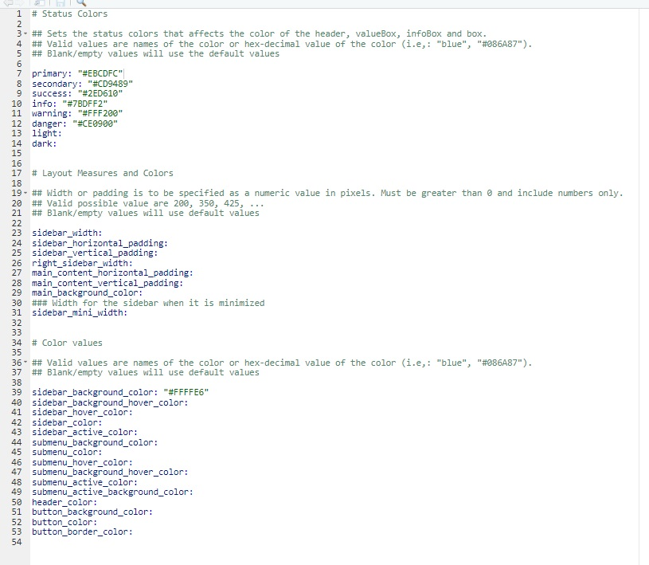

#### www/css

Advanced css customization should go in this location

#### www/js

Advanced js customization should go in this location

#### www/img

Application images can be stored here

**Vignettes**

- downloadFile Module
- downloadableTable Module
- downloadablePlot Module
- logViewer Module
- applicationReset Module
- announcement Module
- Announcement Configuration Builder
- Theme Configuration Builder
- downloadableReactTable Module